# Project 3: Joining CSV files

For analysis, we are using two databases. One has US census data from 2010 by zipcode. The other has US income tax information from 2010 by zip code. In analysis, we will employ joins and piping techniques to wrangle the data in order to produce interesting visualizations.

### Reproducing Our Work:

1. Create a GitHub repository for the project.
2. Create the folders for your project.
3. Find a csv file for statistical comparisons. Our CSV files were found on www.data.gov.
4. Import CSV into SQL Developer
5. Build an html file to document these steps.

Before generating plots, we run the ‘require.r’ file to make sure the necessary packages are in place.

```r
source("../require.R")
```

```
##
##
##
##
##
##
## Registering fonts with R
```

### Summary and Subset:

The SQL used on the table selects all census and income information. A summary and head are displayed for each data frame.

```r
source("../01 Data/summary.R", echo = TRUE)
```

```
##
## > census <- data.frame(fromJSON(getURL(URLencode("129.152.144.84:5001/rest/native/?query=\"select * from CENSUSDATA\""),
## +     httpheader = c(DB = "j ..." ... [TRUNCATED]
##
## > head(census, 10)
##      ZIP POPULATION POPULATIONMALE POPULATIONFEMALE MEDIANAGE
## 1  10526       1809            869              940      43.6
## 2  10527        908            459              449      42.6
## 3  10528      12280           5868             6412      40.6
## 4   1053       1685            840              845      52.1
## 5  10530      12604           5733             6871      47.3
## 6  10532       4931           2423             2508      43.1
## 7  10533       7322           3480             3842      44.0
## 8  10535        555            266              289      40.0
## 9  10536      10739           5257             5482      43.5
## 10 10537       2416           1214             1202      39.7
##    MEDIANAGEMALE MEDIANAGEFEMALE POPULATIONRACEWHITE POPULATIONRACEBLACK
## 1           41.9            44.7              0.8706              0.0249
## 2           42.6            42.6              0.9196              0.0110
## 3           39.7            41.4              0.7845              0.0091
## 4           51.7            52.8              0.9080              0.0273
## 5           45.1            49.5              0.6834              0.0738
## 6           41.5            44.3              0.8741              0.0140
## 7           42.6            44.8              0.8235              0.0138
## 8           40.0            40.1              0.6937              0.0486
## 9           43.6            43.5              0.8942              0.0104
## 10          39.4            40.1              0.7599              0.0493
##    POPULATIONAMERINDIAN POPULATIONRACEASIAN POPULATIONRACEPACIFIC
## 1                0.0006              0.0232                0.0000
## 2                0.0000              0.0176                0.0000
## 3                0.0002              0.0922                8.1400
## 4                0.0018              0.0125                0.0006
## 5                0.0013              0.1161                0.0003
## 6                0.0002              0.0306                0.0002
## 7                0.0007              0.0824                0.0000
## 8                0.0018              0.0360                0.0000
## 9                0.0005              0.0238                9.3100
## 10               0.0008              0.0153                0.0000
##    POPULATIONRACEOTHER POPULATIONRACEMULTI POPULATIONRACELATINO HOUSEHOLDS
## 1               0.0006              0.0193               0.0608        674
```

[output cut: 355 more lines]

```
##  Max.   :2354.00   Max.   :23402        Max.   :9538.0
##  HOUSEHOLDS2PERSON HOUSEHOLDS3PERSON HOUSEHOLDS4PERSON HOUSEHOLDS5PERSON
##  Min.   :    0     Min.   :   0      Min.   :   0.0    Min.   :   0.0
##  1st Qu.:  168     1st Qu.:  51      1st Qu.:  32.0    1st Qu.:  15.0
##  Median :  612     Median : 207      Median : 137.0    Median :  64.0
##  Mean   : 1925     Mean   : 738      Mean   : 496.2    Mean   : 239.2
##  3rd Qu.: 2655     3rd Qu.: 999      3rd Qu.: 661.0    3rd Qu.: 299.0
##  Max.   :28985     Max.   :9901      Max.   :7289.0    Max.   :4264.0
##  HOUSEHOLDS6PERSON HOUSEHOLDS7PLUSPERSON
##  Min.   :   0.00   Min.   :   0.00
##  1st Qu.:   6.00   1st Qu.:   3.00
##  Median :  23.00   Median :  13.00
##  Mean   :  96.15   Mean   :  69.55
##  3rd Qu.: 106.00   3rd Qu.:  58.00
##  Max.   :2509.00   Max.   :4444.00
```

### Plot #1:

First, the income and census data frames were joined by zip code using a dpylr inner join function. Then, two new columns were added to the new table. We found the percentage of single mother households in each zip code, and then made another new column to analyze them by percentile. (singleMotherP and mother_percentile)

Next, we found the average salaries and wages reported on each income tax return by the population size in each zip code. (avgIncome)

We then classified each zip code by its relative population size using the cumulative distribution of the size of the population. The categories “Small”, “Medium”, and “Large” represent the smallest third, medium third, and largest zip codes by population size percentile.

Finally, we mutated the average income column into percentiles for analysis and facet wrapped them for easy viewing.

The first interesting thing about this plot is that there is a solid correlation between zip code population size and average salaries/wages per individual in that population. Secondly, we notice that the large zip code areas appear to have more single mother households than the small zip code areas. The medium size zip codes are perfectly in the middle.

Finally, it appears that zip codes with more single mothers tend to have relatively smaller wages/salaries per individual - note the heavy grouping of points in the top left of each zip code size grouping. Also note here is that there is a shift toward higher relative salary AND higher relative single mother house holds per zip code the larger the zip code is.

Leading Questions About this Data: 1. Are single mother households forced to take lesser paying jobs to take care of their children? (The classic career for child sacrifice)

2. Why does increasing zip code population size correlate with increased single mother households AND increased salaries per person?

```
##
## > census <- data.frame(fromJSON(getURL(URLencode("129.152.144.84:5001/rest/native/?query=\"select * from CENSUSDATA\""),
## +     httpheader = c(DB = "j ..." ... [TRUNCATED]
##
## > income <- data.frame(fromJSON(getURL(URLencode("129.152.144.84:5001/rest/native/?query=\"select * from INCOMEDATA\""),
## +     httpheader = c(DB = "j ..." ... [TRUNCATED]
##
## > join <- dplyr::inner_join(census, income, by = "ZIP") %>%
## +     tbl_df
##
## > join <- join %>% mutate(pop_percent = cume_dist(POPULATION))
##
## > join <- within(join, singleMotherP <- SINGLEMOTHERHOUSEHOLD/HOUSEHOLDS)
##
## > join <- join %>% mutate(mother_percentile = cume_dist(singleMotherP))
##
## > join <- within(join, avgIncome <- SALARIESWAGES/POPULATION)
##
## > levels <- c(0, 0.33, 0.66, 1)
##
## > labels <- c("Small", "Medium", "Large")
##
## > join <- join %>% mutate(PopSize = cut(pop_percent,
## +     levels, labels = labels))
##
## > join %>% mutate(salwages_percent = cume_dist(avgIncome)) %>%
## +     ggplot(aes(x = salwages_percent, y = mother_percentile)) +
## +     geom_point(aes .... [TRUNCATED]
```

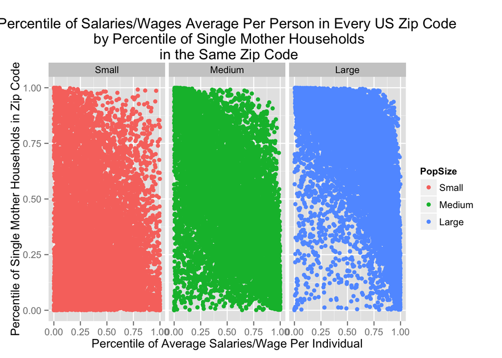

```r
source("../02 Data Wrangling/plot1.R", echo = TRUE)
```

### Plot #2:

Next, we found the average AGI (Adjustable Gross Income) reported on each tax return by the population size in each zip code. (avgAGIncome)

Finally, we mutated the average income column into percentiles for analysis and facet wrapped them for easy viewing.

The first interesting thing about this plot is that it is related to the previous plot. Zip codes with a higher Net Income have more husband wife households with Higher AGI. Similarly, those with smaller Net Income have less husband wife households with Lower AGI.

Leading Questions About this Data: 1. Is the inverse relationship because with more couples with high Net Income the less likley the wife has to work? The low AGI could be that the wife makes no money andthe husband makes enough for both.

2. The relation between the graphs is not surprising. But why does it seem so perfectly inverted? Is it just because there are many data points?

```
##
## > join <- dplyr::inner_join(census, income, by = "ZIP") %>%
## +     tbl_df
##
## > join <- join %>% mutate(net_income = cume_dist(NETINCOME))
##
## > join <- within(join, twoparentP <- HUSBANDWIFEHOUSEHOLDS/HOUSEHOLDS)
##
## > join <- join %>% mutate(twoparent_percentile = cume_dist(twoparentP))
##
## > join <- within(join, avgAGIncome <- ADJUSTGROSSINCOME/POPULATION)
##
## > levels <- c(0, 0.33, 0.66, 1)
##
## > labels <- c("Small", "Medium", "Large")
##
## > join <- join %>% mutate(NetIncome = cut(net_income,
## +     levels, labels = labels))
##
## > join %>% mutate(netinc_percent = cume_dist(avgAGIncome)) %>%
## +     ggplot(aes(x = netinc_percent, y = twoparent_percentile)) +
## +     geom_point(ae .... [TRUNCATED]
```

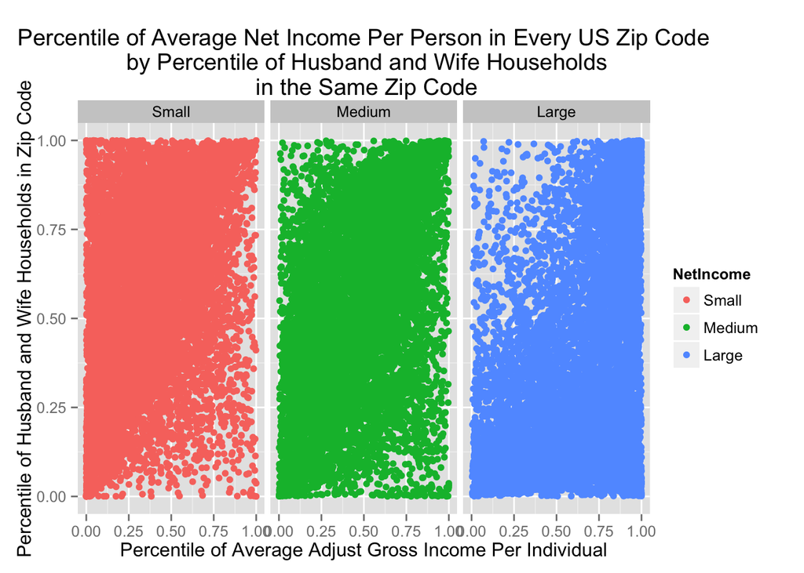

```r
source("../02 Data Wrangling/plot2.R", echo = TRUE)
```

### Plot #3:

Next, we found the ratio of households with seven or more people to the total number of households. (SevenPlusRatio)

We then classified each zip code by its relative population size using the cumulative distribution of the size of the population. The categories “Small” and “Large” represent the lower and upper half of zipcodes by population.

Finally, we mutated the ratio column into percentiles for analysis and placed them on the x-axis with the Latino population average on the Y axis.

Without the seperation of “small” and “large” you can’t tell much on what is going on due to the many many data points. So since there is a seperation, you can see the correlation of higher percent of of households with seven or more people and a higher latino population.

We tried this method with other races provided and the Latino curve showed the most. We decided to leave out the other facet wrap because it would have made the total visualization much too crowded.

Leading Questions About this Data: 1. Is this data accurate today? SInce this data is from 2010 I wonder if older or more modern data would show the same trend.

2. This seems to imply the known stereotype the Latino families are usually much larger.

```
##
## > join <- dplyr::inner_join(census, income, by = "ZIP") %>%
## +     tbl_df
##
## > join <- join %>% mutate(pop_percent = cume_dist(POPULATION))
##
## > join <- within(join, SevenPlusRatio <- HOUSEHOLDS7PLUSPERSON/HOUSEHOLDS)
##
## > levels <- c(0, 0.5, 1)
##
## > labels <- c("Small", "Large")
##
## > join <- join %>% mutate(PopSize = cut(pop_percent,
## +     levels, labels = labels))
##
## > join %>% mutate(SevenPlusPercent = cume_dist(SevenPlusRatio)) %>%
## +     ggplot(aes(x = SevenPlusPercent, y = POPULATIONRACELATINO)) +
## +     geom_p .... [TRUNCATED]
```

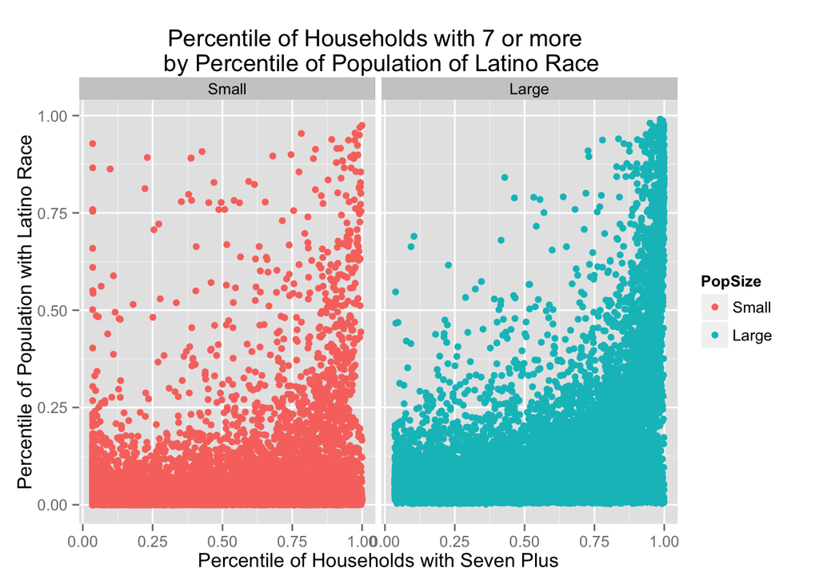

```r
source("../02 Data Wrangling/plot3.R", echo = TRUE)
```